# HarvardX PH125.4x Data Science: Inference and Modeling

# Properties of Our Estimate

[][*To understand how good our estimate is, we’ll describe the statistical properties of the random variable we just defined*], the sample proportion. Note that if we multiply by N, **N times X bar is the sum of independent draws. So the rules we cover in the probability module apply**. Using what we have learned, the expected value of the sum N times X bar is N times the average of the urn, p. So dividing by the non-random constant N gives us that the expected value of the average X bar is p. We can write it using our mathematical notation like this. We also can use what we learned to figure out the standard error. [][*We know that the standard error of the sum is square root of N times a standard deviation of the values in the urn*].

Can we compute the standard error of the urn? We learn a formula that tells us that it’s 1 minus 0 times the square root of p times 1 minus p, which is the square root of p times 1 minus p. Because we are dividing by the sum N, we arrive at the following formula for the standard error of the average. The standard error of the average is square root of p times 1 minus p divided by the square root of N. This result reveals the power of polls. The expected value of the sample proportion X bar is the parameter of interest p, and we can make the standard error as small as we want by increasing the sample size N. The law of large numbers tells us that with a large enough poll, our estimate converges to p.

[][Textbook link]

This video corresponds to the textbook section on properties of our estimate. https://rafalab.github.io/dsbook/inference.html#properties-of-our-estimate-expected-value-and-standard-error

[][Key points]

[][* When interpreting values of X_bar, it is important to remember that X_bar is a random variable with an expected value and standard error that represents the sample proportion of positive events.*] The expected value of X_bar is the parameter of interest p. This follows from the fact that X_bar is the sum of independent draws of a random variable times a constant 1/N. E(X_bar) = p As the number of draws N increases, the standard error of our estimate X_bar decreases. The standard error of the average of X_bar over N draws is: SE(X_bar) = sqrt(p(1-p)/N)

```
    In theory, we can get more accurate estimates of p by increasing N. In practice, there are limits on the size of N due to costs, as well as other factors we discuss later.
We can also use other random variable equations to determine the expected value of the sum of draws E(S) and standard error of the sum of draws SE(S).
    E(X) = Np
    SE(S) = sqrt(Np(1-p))
```

[figure not shown]

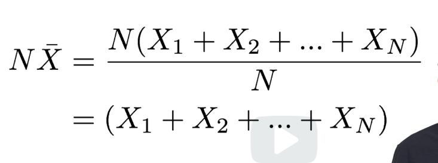

[figure not shown]

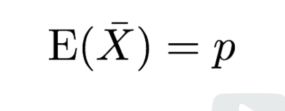

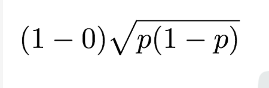

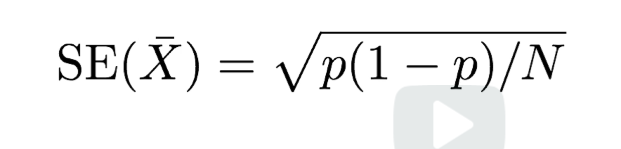

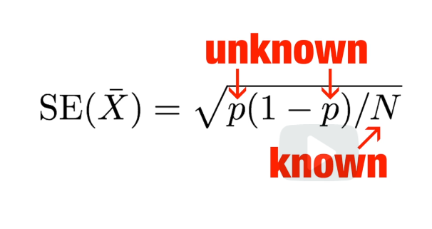

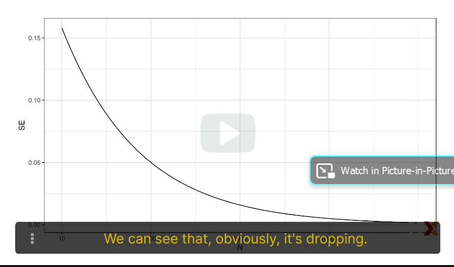

[figure not shown]

[figure not shown]

# Assessment 1.1: Parameters and Estimates

DataCamp due Jul 8, 2022 02:35 AWST

In this assessment, you will learn about parameters and estimates using the example of election polling.

By clicking OK, you agree to DataCamp’s privacy policy: https://www.datacamp.com/privacy-policy. Note that you might need to disable your pop-up blocker, or allow “www.datacamp.com” in your pop-up blocker allowed list. When you have completed the exercises, return to edX to continue your learning.

Ask your questions about parameters and estimates or the related DataCamp assessment here. Remember to search the discussion board before posting to see if someone else has asked the same thing before asking a new question! You’re also encouraged to answer each other’s questions to help further your own learning.

Some reminders:

```
Please be specific in the title and body of your post regarding which question you're asking about to facilitate answering your question.
Posting snippets of code is okay, but posting full code solutions is not.
If you do post snippets of code, please format it as code for readability. If you're not sure how to do this, there are instructions in a pinned post in the "general" discussion forum.
```

[output not shown]

## Exercise 1. Polling - expected value of S

# =========================================================================================================

Suppose you poll a population in which a proportion p of voters are Democrats and 1-p are Republicans. Your sample size is N=25. Consider the random variable S, which is the total number of Democrats in your sample.

What is the expected value of this random variable S? Instructions 50 XP Possible Answers

E(S) = 25(1-p) E(S) = 25p E(S) = sqrt(25p(1-p)) E(S) = p

## Exercise 2. Polling - standard error of S

Again, consider the random variable S, which is the total number of Democrats in your sample of 25 voters. The variable p describes the proportion of Democrats in the sample, whereas 1-p describes the proportion of Republicans.

What is the standard error of S? Instructions 50 XP Possible Answers

SE(S) = 25p(1-p) SE(S) = sqrt(25p) SE(S) = 25(1-p) SE(S) = sqrt(25*p(1-p))

## Exercise 3. Polling - expected value of X-bar

Consider the random variable S/N, which is equivalent to the sample average that we have been denoting as X_bar. The variable N represents the sample size and p is the proportion of Democrats in the population.

What is the expected value of X_bar? Instructions 50 XP Possible Answers

E(X_bar) = p E(X_bar) = Np E(X_bar) = N(1-p) E(X_bar) = 1-p

## Exercise 4. Polling - standard error of X-bar

What is the standard error of the sample average, X_bar?

The variable N represents the sample size and p is the proportion of Democrats in the population. Instructions 50 XP Possible Answers

SE(X_bar) = sqrt(Np(1-p)) SE(X_bar) = sqrt(p(1-p)/N) SE(X_bar) = sqrt(p(1-p)) SE(X_bar) = sqrt(N)

## Exercise 5. se versus p

Write a line of code that calculates the standard error se of a sample average when you poll 25 people in the population. Generate a sequence of 100 proportions of Democrats p that vary from 0 (no Democrats) to 1 (all Democrats).

Plot se versus p for the 100 different proportions. Instructions 100 XP

```
Use the seq function to generate a vector of 100 values of p that range from 0 to 1.
Use the sqrt function to generate a vector of standard errors for all values of p.
Use the plot function to generate a plot with p on the x-axis and se on the y-axis.
```

```r
# `N` represents the number of people polled
N <- 25

# Create a variable `p` that contains 100 proportions ranging from 0 to 1 using the `seq` function
p <- seq(0, 1, 1/100)
p
```

```
##   [1] 0.00 0.01 0.02 0.03 0.04 0.05 0.06 0.07 0.08 0.09 0.10 0.11 0.12 0.13 0.14
##  [16] 0.15 0.16 0.17 0.18 0.19 0.20 0.21 0.22 0.23 0.24 0.25 0.26 0.27 0.28 0.29
##  [31] 0.30 0.31 0.32 0.33 0.34 0.35 0.36 0.37 0.38 0.39 0.40 0.41 0.42 0.43 0.44
##  [46] 0.45 0.46 0.47 0.48 0.49 0.50 0.51 0.52 0.53 0.54 0.55 0.56 0.57 0.58 0.59
##  [61] 0.60 0.61 0.62 0.63 0.64 0.65 0.66 0.67 0.68 0.69 0.70 0.71 0.72 0.73 0.74
##  [76] 0.75 0.76 0.77 0.78 0.79 0.80 0.81 0.82 0.83 0.84 0.85 0.86 0.87 0.88 0.89
##  [91] 0.90 0.91 0.92 0.93 0.94 0.95 0.96 0.97 0.98 0.99 1.00
```

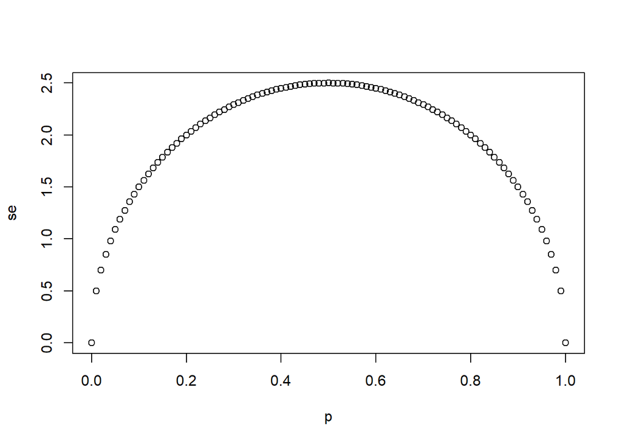

```r
# Create a variable `se` that contains the standard error of each sample average
se <- sqrt(N*p*(1-p))

# Plot `p` on the x-axis and `se` on the y-axis
plot(p, se)
```

Incorrect submission Check your call of seq(). Did you specify the argument length.out? Incorrect submission Use sqrt to calculate the standard error and save it as se. Make sure to specify the correct formula for standard error.

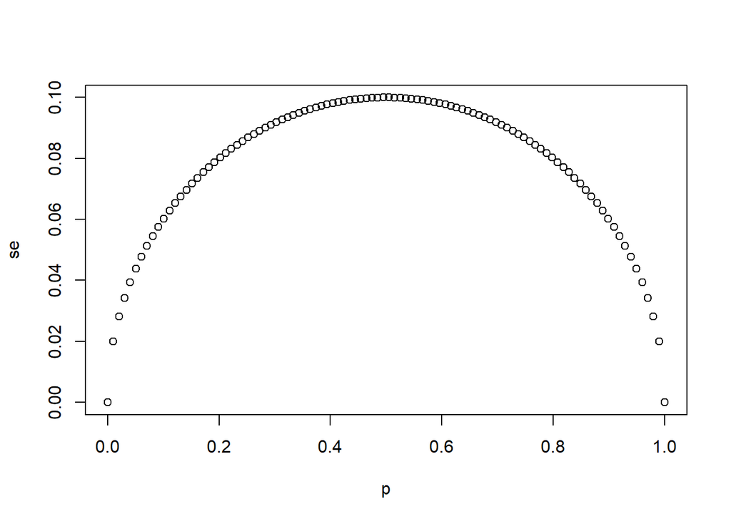

```r
# `N` represents the number of people polled
N <- 25

# Create a variable `p` that contains 100 proportions ranging from 0 to 1 using the `seq` function
p <- seq(0, 1, length.out=100)

# Create a variable `se` that contains the standard error of each sample average
se <- sqrt(p*(1-p)/N)

# Plot `p` on the x-axis and `se` on the y-axis
plot(p, se)
```

## Exercise 6. Multiple plots of se versus p

Using the same code as in the previous exercise, create a for-loop that generates three plots of p versus se when the sample sizes equal N = 25, N = 100, N = 1000. Instructions 100 XP

```
Your for-loop should contain two lines of code to be repeated for three different values of N.
The first line within the for-loop should use the sqrt function to generate a vector of standard errors se for all values of p.
The second line within the for-loop should use the plot function to generate a plot with p on the x-axis and se on the y-axis.
Use the ylim argument to keep the y-axis limits constant across all three plots. The lower limit should be equal to 0 and the upper limit should equal 0.1 (it can be shown that this value is the highest calculated standard error across all values of p and N).
```

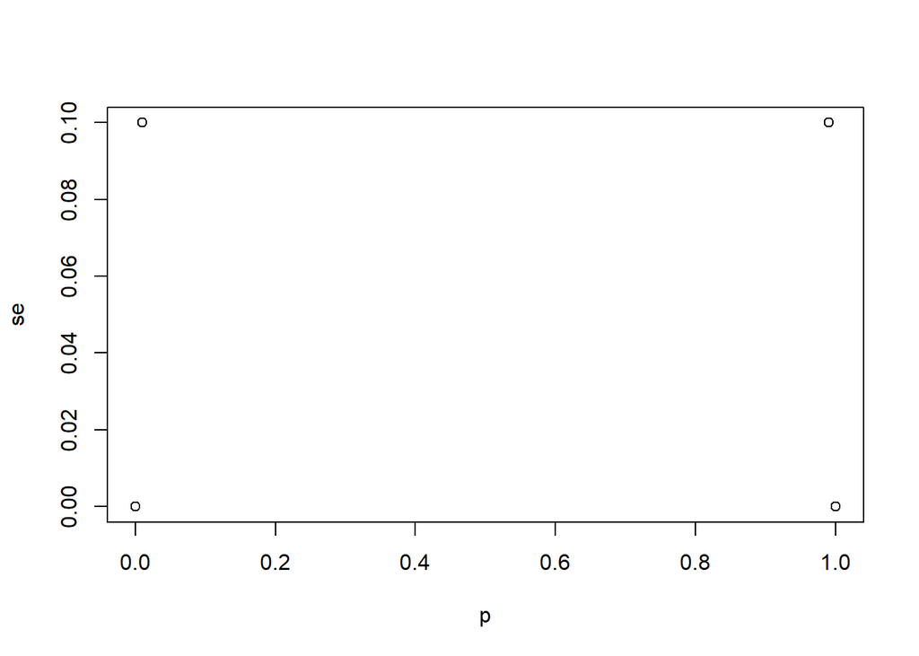

```r
# The vector `p` contains 100 proportions of Democrats ranging from 0 to 1 using the `seq` function
p <- seq(0, 1, length = 100)

# The vector `sample_sizes` contains the three sample sizes
sample_sizes <- c(25, 100, 1000)

# Write a for-loop that calculates the standard error `se` for every value of `p` for each of the three samples sizes `N` in the vector `sample_sizes`. Plot the three graphs, using the `ylim` argument to standardize the y-axis across all three plots.
se <- sqrt(p*(1-p))
plot(p, se, ylim=c(0, 0.1))
```

Exercise 6. Multiple plots of se versus p

```
Your for-loop should contain two lines of code to be repeated for three different values of N.
The first line within the for-loop should use the sqrt function to generate a vector of standard errors se for all values of p.
The second line within the for-loop should use the plot function to generate a plot with p on the x-axis and se on the y-axis.
Use the ylim argument to keep the y-axis limits constant across all three plots. The lower limit should be equal to 0 and the upper limit should equal 0.1 (it can be shown that this value is the highest calculated standard error across all values of p and N).
```

Hint

[output not shown]

for(N in sample_sizes){ example_line1 example_line2 }

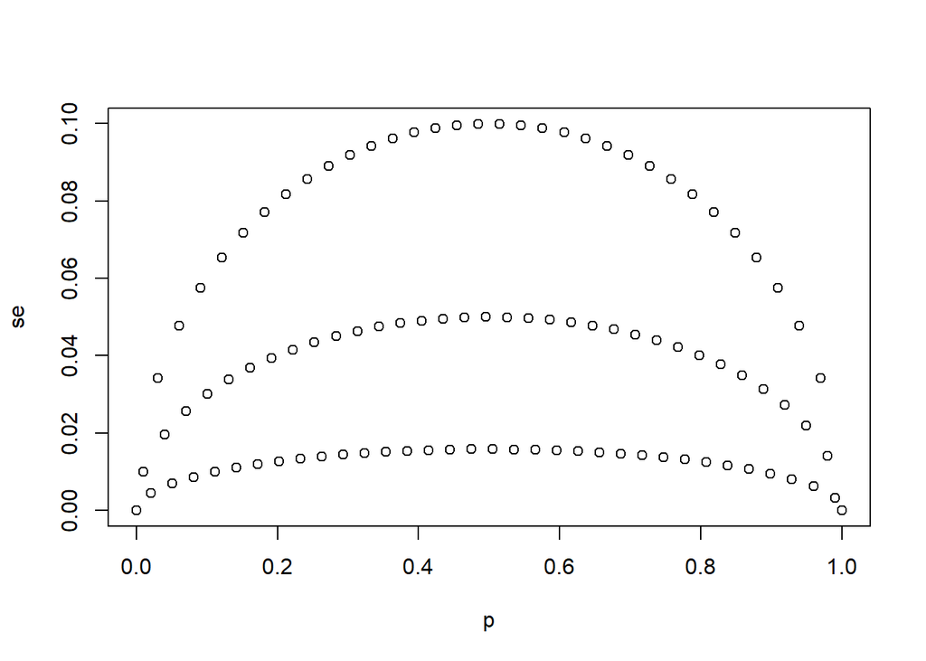

```r
# The vector `p` contains 100 proportions of Democrats ranging from 0 to 1 using the `seq` function
p <- seq(0, 1, length = 100)

# The vector `sample_sizes` contains the three sample sizes
sample_sizes <- c(25, 100, 1000)

# Write a for-loop that calculates the standard error `se` for every value of `p` for each of the three samples sizes `N` in the vector `sample_sizes`. Plot the three graphs, using the `ylim` argument to standardize the y-axis across all three plots.
se <- sqrt(p*(1-p)/sample_sizes)
plot(p, se, ylim=c(0, 0.1))
```

Incorrect submission Make sure to write a for-loop using for.

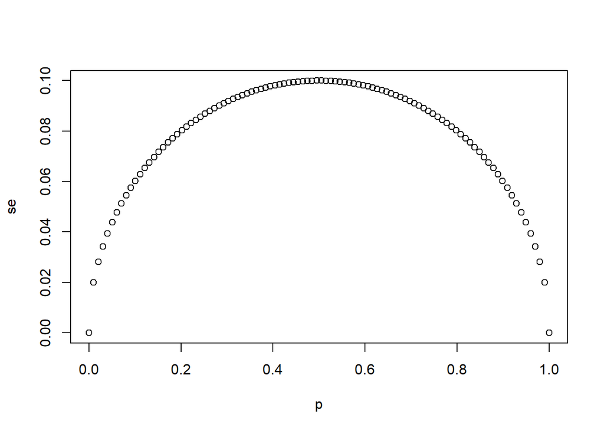

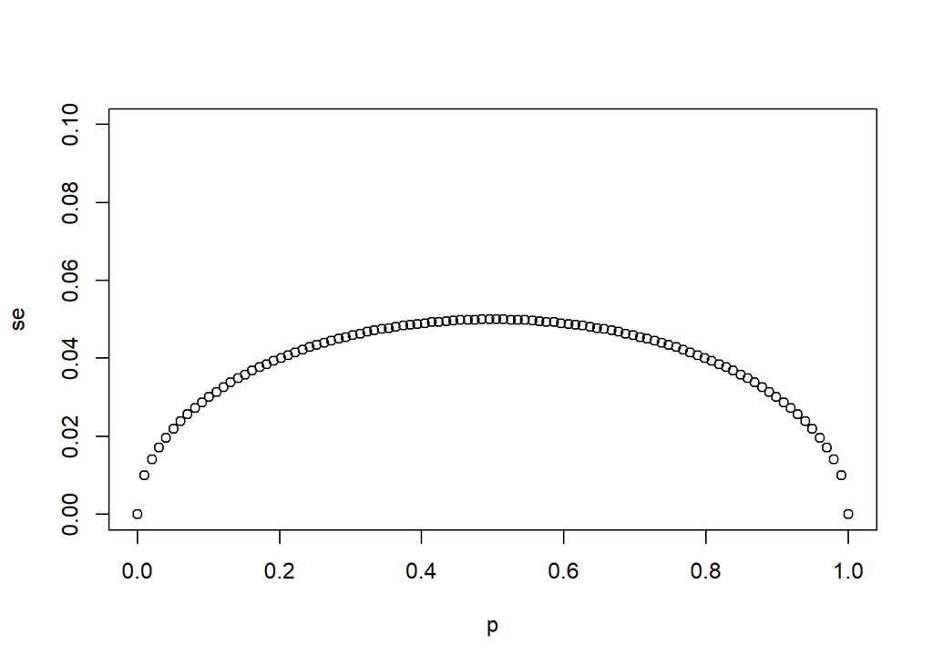

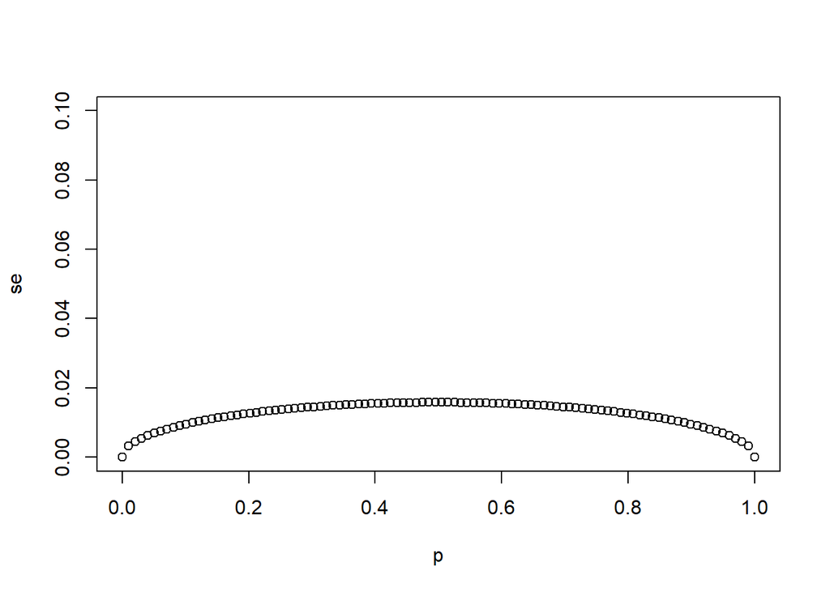

```r
# The vector `p` contains 100 proportions of Democrats ranging from 0 to 1 using the `seq` function
p <- seq(0, 1, length = 100)

# The vector `sample_sizes` contains the three sample sizes
sample_sizes <- c(25, 100, 1000)

# Write a for-loop that calculates the standard error `se` for every value of `p` for each of the three samples sizes `N` in the vector `sample_sizes`. Plot the three graphs, using the `ylim` argument to standardize the y-axis across all three plots.
for (N in sample_sizes) {
  se <- sqrt(p*(1-p)/N)
  plot(p, se, ylim=c(0, 0.1))
}
```

## Exercise 7. Expected value of d

Our estimate for the difference in proportions of Democrats and Republicans is d = X_bar - (1-X_bar).

Which derivation correctly uses the rules we learned about sums of random variables and scaled random variables to derive the expected value of d? Instructions 50 XP Possible Answers

E[X_bar-(1-X_bar)] = E[2X_bar-1] = 2E[X_bar]-1 = N(2p-1) = Np-N(1-p) E[X_bar-(1-X_bar)] = E[X_bar-1] = E[X_bar]-1 = p-1 E[X_bar-(1-X_bar)] = E[2X_bar-1] = 2sqrt(p(1-p))-1 = p-(1-p) E[X_bar-(1-X_bar)] = E[2X_bar-1] = 2p-1 = p-(1-p) O # ================================================================================

## Exercise 8. Standard error of d

Our estimate for the difference in proportions of Democrats and Republicans is d = X_bar - (1-X_bar).

Which derivation correctly uses the rules we learned about sums of random variables and scaled random variables to derive the standard error of d? Instructions 50 XP Possible Answers

SE[X_bar-(1-X_bar)] = SE[2X_bar-1] = 2SE[X_bar] = 2sqrt(p/N) SE[X_bar-(1-X_bar)] = SE[2X_bar-1] = 2SE[X_bar-1] = 2sqrt(p(1-p)/N)-1 SE[X_bar-(1-X_bar)] = SE[2X_bar-1] = 2SE[X_bar] = 2sqrt(p(1-p)/N) O SE[X_bar-(1-X_bar)] = SE[X_bar-1] = SE[X_bar] = sqrt(p(1-p)/N)

Incorrect submission Try again. Subtracting 1 does not affect the standard error. # ================================================================================

## Exercise 9. Standard error of the spread

Say the actual proportion of Democratic voters is p=0.45. In this case, the Republican party is winning by a relatively large margin of d=-0.1, or a 10% margin of victory. What is the standard error of the spread 2X_bar-1 in this case? Instructions 100 XP

```
Use the sqrt function to calculate the standard error of the spread 2X_bar-1.
```

```r
# `N` represents the number of people polled
N <- 25

# `p` represents the proportion of Democratic voters
p <- 0.45

# Calculate the standard error of the spread. Print this value to the console.
2*sqrt(p*(1-p)/N)
```

```
## [1] 0.1989975
```

## Exercise 10. Sample size

So far we have said that the difference between the proportion of Democratic voters and Republican voters is about 10% and that the standard error of this spread is about 0.2 when N=25. Select the statement that explains why this sample size is sufficient or not. Instructions 50 XP Possible Answers

```
This sample size is sufficient because the expected value of our estimate 2X_bar-1 is d so our prediction will be right on.
```

[][* This sample size is too small because the standard error is larger than the spread. O*] This sample size is sufficient because the standard error of about 0.2 is much smaller than the spread of 10%. Without knowing p, we have no way of knowing that increasing our sample size would actually improve our standard error. # ======================================================================================================= # ========================================================= What is the spread the instructor mentioned here and above

## End of Assessment

This is the end of the programming assignment for this section. Please DO NOT click through to additional assessments from this page. If you do click through, your scores may NOT be recorded.

Click “Got it!” and submit to get the “points” for this question.

You can close this window and return to Data Science: Inference. Answer the question 50XP Possible Answers

```
Got it!
press
1
```

## Course / Section 2: The Central Limit Theorem in Practice / Section 2 Overview

# Section 2 Overview

In Section 2, you will look at the Central Limit Theorem in practice.

After completing Section 2, you will be able to:

```
    Use the Central Limit Theorem to calculate the probability that a sample estimate X_bar is close to the population proportion p.
    Run a Monte Carlo simulation to corroborate theoretical results built using probability theory.
    Estimate the spread based on estimates of X_bar and SE_hat(X_bar).
    Understand why bias can mean that larger sample sizes aren't necessarily better.
```

There is 1 assignment that uses the DataCamp platform for you to practice your coding skills.

We encourage you to use R to interactively test out your answers and further your learning.

## Course / Section 2: The Central Limit Theorem in Practice / Central Limit Theorem in Practice

# The Central Limit Theorem in Practice